# Part I - Prosper Loan Data Exploration

## by Lakshmi Madhuri Jeereddi

## Preliminary Wrangling

```python
# import all packages and set plots to be embedded inline
import numpy as np
import pandas as pd
import matplotlib.pyplot as plt
import seaborn as sb

%matplotlib inline
import warnings
warnings.simplefilter("ignore")
```

```python
# load in the dataset into a pandas dataframe
df = pd.read_csv('prosperLoanData.csv')
```

```python
# overview of the data
df.shape
```

```
(113937, 81)
```

```python
df.info()
```

```
<class 'pandas.core.frame.DataFrame'>
RangeIndex: 113937 entries, 0 to 113936
Data columns (total 81 columns):
 #   Column                               Non-Null Count   Dtype
---  ------                               --------------   -----
 0   ListingKey                           113937 non-null  object
 1   ListingNumber                        113937 non-null  int64
 2   ListingCreationDate                  113937 non-null  object
 3   CreditGrade                          28953 non-null   object
 4   Term                                 113937 non-null  int64
 5   LoanStatus                           113937 non-null  object
 6   ClosedDate                           55089 non-null   object
 7   BorrowerAPR                          113912 non-null  float64
 8   BorrowerRate                         113937 non-null  float64
 9   LenderYield                          113937 non-null  float64
```

[output cut: 73 more lines]

Data Assessing and cleaning :-

1. create subset
2. drop duplicates
3. convert datatypes
4. fill missing values

```python
columns = ["ListingKey","ListingNumber","ListingCreationDate","ListingCategory (numeric)","LoanStatus","ClosedDate","Term","BorrowerAPR","BorrowerRate","ProsperRating (Alpha)","ProsperScore","Occupation","EmploymentStatus",
           "CreditScoreRangeLower","CreditScoreRangeUpper","DateCreditPulled","DebtToIncomeRatio","StatedMonthlyIncome","LoanOriginalAmount","MonthlyLoanPayment","AmountDelinquent","IncomeRange"]
loan = df[columns]
```

```python
loan.info()
```

```
<class 'pandas.core.frame.DataFrame'>
RangeIndex: 113937 entries, 0 to 113936
Data columns (total 22 columns):
 #   Column                     Non-Null Count   Dtype
---  ------                     --------------   -----
 0   ListingKey                 113937 non-null  object
 1   ListingNumber              113937 non-null  int64
 2   ListingCreationDate        113937 non-null  object
 3   ListingCategory (numeric)  113937 non-null  int64
 4   LoanStatus                 113937 non-null  object
 5   ClosedDate                 55089 non-null   object
 6   Term                       113937 non-null  int64
 7   BorrowerAPR                113912 non-null  float64
 8   BorrowerRate               113937 non-null  float64
 9   ProsperRating (Alpha)      84853 non-null   object
 10  ProsperScore               84853 non-null   float64
 11  Occupation                 110349 non-null  object
 12  EmploymentStatus           111682 non-null  object
 13  CreditScoreRangeLower      113346 non-null  float64
 14  CreditScoreRangeUpper      113346 non-null  float64
 15  DateCreditPulled           113937 non-null  object
 16  DebtToIncomeRatio          105383 non-null  float64
 17  StatedMonthlyIncome        113937 non-null  float64
 18  LoanOriginalAmount         113937 non-null  int64
 19  MonthlyLoanPayment         113937 non-null  float64
 20  AmountDelinquent           106315 non-null  float64
 21  IncomeRange                113937 non-null  object
dtypes: float64(9), int64(4), object(9)
memory usage: 19.1+ MB
```

```python
loan.head()
```

|  | ListingKey | ListingNumber | ListingCreationDate | ListingCategory (numeric) | LoanStatus | ClosedDate | Term | BorrowerAPR | BorrowerRate | ProsperRating (Alpha) | ... | EmploymentStatus | CreditScoreRangeLower | CreditScoreRangeUpper | DateCreditPulled | DebtToIncomeRatio | StatedMonthlyIncome | LoanOriginalAmount | MonthlyLoanPayment | AmountDelinquent | IncomeRange |
| --- | --- | --- | --- | --- | --- | --- | --- | --- | --- | --- | --- | --- | --- | --- | --- | --- | --- | --- | --- | --- | --- |
| 0 | 1021339766868145413AB3B | 193129 | 2007-08-26 19:09:29.263000000 | 0 | Completed | 2009-08-14 00:00:00 | 36 | 0.16516 | 0.1580 | NaN | ... | Self-employed | 640.0 | 659.0 | 2007-08-26 18:41:46.780000000 | 0.17 | 3083.333333 | 9425 | 330.43 | 472.0 | $25,000-49,999 |
| 1 | 10273602499503308B223C1 | 1209647 | 2014-02-27 08:28:07.900000000 | 2 | Current | NaN | 36 | 0.12016 | 0.0920 | A | ... | Employed | 680.0 | 699.0 | 2014-02-27 08:28:14 | 0.18 | 6125.000000 | 10000 | 318.93 | 0.0 | $50,000-74,999 |
| 2 | 0EE9337825851032864889A | 81716 | 2007-01-05 15:00:47.090000000 | 0 | Completed | 2009-12-17 00:00:00 | 36 | 0.28269 | 0.2750 | NaN | ... | Not available | 480.0 | 499.0 | 2007-01-02 14:09:10.060000000 | 0.06 | 2083.333333 | 3001 | 123.32 | NaN | Not displayed |
| 3 | 0EF5356002482715299901A | 658116 | 2012-10-22 11:02:35.010000000 | 16 | Current | NaN | 36 | 0.12528 | 0.0974 | A | ... | Employed | 800.0 | 819.0 | 2012-10-22 11:02:32 | 0.15 | 2875.000000 | 10000 | 321.45 | 10056.0 | $25,000-49,999 |
| 4 | 0F023589499656230C5E3E2 | 909464 | 2013-09-14 18:38:39.097000000 | 2 | Current | NaN | 36 | 0.24614 | 0.2085 | D | ... | Employed | 680.0 | 699.0 | 2013-09-14 18:38:44 | 0.26 | 9583.333333 | 15000 | 563.97 | 0.0 | $100,000+ |

5 rows × 22 columns

```python
loan.duplicated().sum()
```

```
0
```

```python
loan[["ListingCreationDate","ClosedDate","DateCreditPulled"]] = loan[["ListingCreationDate","ClosedDate","DateCreditPulled"]].apply(pd.to_datetime)
```

```python
loan['ListingCreationDate'] = pd.to_datetime(df['ListingCreationDate']).dt.date
loan['ClosedDate'] = pd.to_datetime(df['ClosedDate']).dt.date
loan['DateCreditPulled'] = pd.to_datetime(df['DateCreditPulled']).dt.date
```

```python
loan['DebtToIncomeRatio'] = loan['DebtToIncomeRatio'].fillna(loan['DebtToIncomeRatio'].mean())
```

```python
loan['DebtToIncomeRatio'].isnull().sum()
```

```
0
```

```python
loan = loan[loan['ProsperScore'].notnull()]
```

```python
loan.info()
```

```
<class 'pandas.core.frame.DataFrame'>
Int64Index: 84853 entries, 1 to 113936
Data columns (total 22 columns):
 #   Column                     Non-Null Count  Dtype
---  ------                     --------------  -----
 0   ListingKey                 84853 non-null  object
 1   ListingNumber              84853 non-null  int64
 2   ListingCreationDate        84853 non-null  object
 3   ListingCategory (numeric)  84853 non-null  int64
 4   LoanStatus                 84853 non-null  object
 5   ClosedDate                 26005 non-null  object
 6   Term                       84853 non-null  int64
 7   BorrowerAPR                84853 non-null  float64
 8   BorrowerRate               84853 non-null  float64
 9   ProsperRating (Alpha)      84853 non-null  object
 10  ProsperScore               84853 non-null  float64
 11  Occupation                 83520 non-null  object
 12  EmploymentStatus           84853 non-null  object
 13  CreditScoreRangeLower      84853 non-null  float64
 14  CreditScoreRangeUpper      84853 non-null  float64
 15  DateCreditPulled           84853 non-null  object
 16  DebtToIncomeRatio          84853 non-null  float64
 17  StatedMonthlyIncome        84853 non-null  float64
 18  LoanOriginalAmount         84853 non-null  int64
 19  MonthlyLoanPayment         84853 non-null  float64
 20  AmountDelinquent           84853 non-null  float64
 21  IncomeRange                84853 non-null  object
dtypes: float64(9), int64(4), object(9)
memory usage: 14.9+ MB
```

```python
loan.head()
```

|  | ListingKey | ListingNumber | ListingCreationDate | ListingCategory (numeric) | LoanStatus | ClosedDate | Term | BorrowerAPR | BorrowerRate | ProsperRating (Alpha) | ... | EmploymentStatus | CreditScoreRangeLower | CreditScoreRangeUpper | DateCreditPulled | DebtToIncomeRatio | StatedMonthlyIncome | LoanOriginalAmount | MonthlyLoanPayment | AmountDelinquent | IncomeRange |
| --- | --- | --- | --- | --- | --- | --- | --- | --- | --- | --- | --- | --- | --- | --- | --- | --- | --- | --- | --- | --- | --- |
| 1 | 10273602499503308B223C1 | 1209647 | 2014-02-27 | 2 | Current | NaT | 36 | 0.12016 | 0.0920 | A | ... | Employed | 680.0 | 699.0 | 2014-02-27 | 0.18 | 6125.000000 | 10000 | 318.93 | 0.0 | $50,000-74,999 |
| 3 | 0EF5356002482715299901A | 658116 | 2012-10-22 | 16 | Current | NaT | 36 | 0.12528 | 0.0974 | A | ... | Employed | 800.0 | 819.0 | 2012-10-22 | 0.15 | 2875.000000 | 10000 | 321.45 | 10056.0 | $25,000-49,999 |
| 4 | 0F023589499656230C5E3E2 | 909464 | 2013-09-14 | 2 | Current | NaT | 36 | 0.24614 | 0.2085 | D | ... | Employed | 680.0 | 699.0 | 2013-09-14 | 0.26 | 9583.333333 | 15000 | 563.97 | 0.0 | $100,000+ |
| 5 | 0F05359734824199381F61D | 1074836 | 2013-12-14 | 1 | Current | NaT | 60 | 0.15425 | 0.1314 | B | ... | Employed | 740.0 | 759.0 | 2013-12-14 | 0.36 | 8333.333333 | 15000 | 342.37 | 0.0 | $100,000+ |
| 6 | 0F0A3576754255009D63151 | 750899 | 2013-04-12 | 1 | Current | NaT | 36 | 0.31032 | 0.2712 | E | ... | Employed | 680.0 | 699.0 | 2013-04-12 | 0.27 | 2083.333333 | 3000 | 122.67 | 0.0 | $25,000-49,999 |

5 rows × 22 columns

```python
loan.describe()
```

|  | ListingNumber | ListingCategory (numeric) | Term | BorrowerAPR | BorrowerRate | ProsperScore | CreditScoreRangeLower | CreditScoreRangeUpper | DebtToIncomeRatio | StatedMonthlyIncome | LoanOriginalAmount | MonthlyLoanPayment | AmountDelinquent |
| --- | --- | --- | --- | --- | --- | --- | --- | --- | --- | --- | --- | --- | --- |
| count | 8.485300e+04 | 84853.000000 | 84853.000000 | 84853.000000 | 84853.000000 | 84853.000000 | 84853.000000 | 84853.000000 | 84853.000000 | 8.485300e+04 | 84853.000000 | 84853.000000 | 84853.000000 |
| mean | 7.738749e+05 | 3.312647 | 42.486135 | 0.226658 | 0.196022 | 5.950067 | 699.390240 | 718.390240 | 0.260230 | 5.931175e+03 | 9083.440515 | 291.930720 | 950.773797 |
| std | 2.363387e+05 | 4.364277 | 11.640346 | 0.079916 | 0.074631 | 2.376501 | 47.095937 | 47.095937 | 0.304371 | 8.239944e+03 | 6287.860058 | 186.678314 | 7419.574684 |
| min | 4.162750e+05 | 0.000000 | 12.000000 | 0.045830 | 0.040000 | 1.000000 | 600.000000 | 619.000000 | 0.000000 | 0.000000e+00 | 1000.000000 | 0.000000 | 0.000000 |
| 25% | 5.580860e+05 | 1.000000 | 36.000000 | 0.163280 | 0.135900 | 4.000000 | 660.000000 | 679.000000 | 0.160000 | 3.434000e+03 | 4000.000000 | 157.330000 | 0.000000 |
| 50% | 7.392460e+05 | 1.000000 | 36.000000 | 0.219450 | 0.187500 | 6.000000 | 700.000000 | 719.000000 | 0.240000 | 5.000000e+03 | 7500.000000 | 251.940000 | 0.000000 |
| 75% | 9.794360e+05 | 3.000000 | 60.000000 | 0.292540 | 0.257400 | 8.000000 | 720.000000 | 739.000000 | 0.310000 | 7.083333e+03 | 13500.000000 | 388.350000 | 0.000000 |
| max | 1.255725e+06 | 20.000000 | 60.000000 | 0.423950 | 0.360000 | 11.000000 | 880.000000 | 899.000000 | 10.010000 | 1.750003e+06 | 35000.000000 | 2251.510000 | 463881.000000 |

### What is the structure of your dataset?

The data set contains 84853 loan with 22 columns information like BorrowerAPR, ProsperScore, DebtToIncomeRatio, MonthlyLoanPayment, e.t.c.,

### What is/are the main feature(s) of interest in your dataset?

I am interested how employment status will effect loan payments and deliquencies and the factors effect borrower loan status and APR for the loan. how debt to income ration effected.

### What features in the dataset do you think will help support your investigation into your feature(s) of interest?

I think loan payments will be effected by employment status and Monthly Loan Payment and APR will be effected by the loan original amount, monthly income, prosper rating employment status and so on.

## Univariate Exploration

le'ts us look at the some of important variebles:-

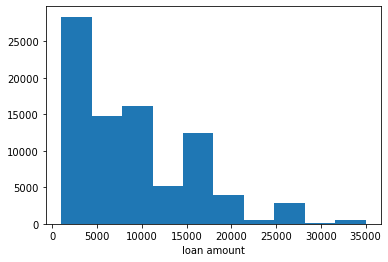

```python
# distribution of loan original amount.
plt.hist(data=loan,x='LoanOriginalAmount')
plt.xlabel('loan amount');
```

By seeing the visulaization we can say that, there are more number of loans with the amount of below 5000K and small number of loans in the amount from 20K to 35K.

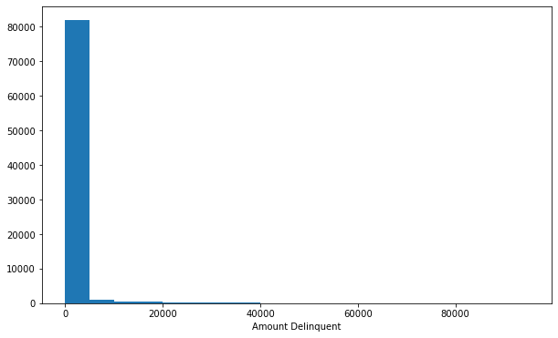

```python
#distribution of AmountDelinquent
plt.figure(figsize=[10,6])
bins = np.arange(0,100000, 5000)
plt.hist(data=loan,x='AmountDelinquent',bins=bins)
plt.xlabel('Amount Delinquent');
```

By seeing the visualization we can say that , the max anount of deliquncies lies from 0 to 10K.

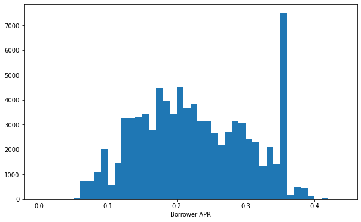

```python
# distribution of BorrowerAPR
plt.figure(figsize=[10,6])
bins =  np.arange(0, loan.BorrowerAPR.max()+0.02, 0.01)
plt.hist(loan['BorrowerAPR'], bins=bins)
plt.xlabel('Borrower APR');
```

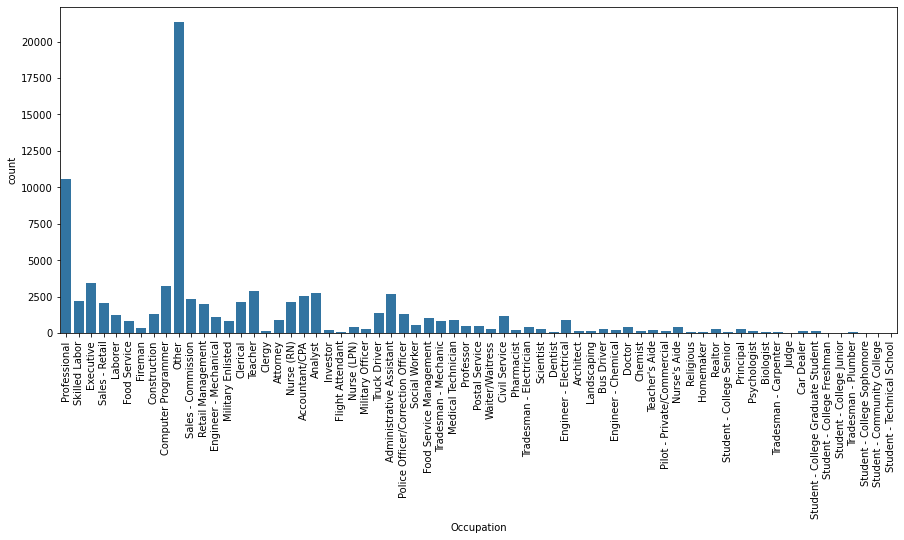

```python
#distribution of Occupation
plt.figure(figsize=[15,6])
color = sb.color_palette()[0]
sb.countplot(data=loan,x='Occupation',color=color)
plt.xlabel('Occupation')
plt.xticks(rotation=90);
```

The most of the borrowers are other and professional. The least borrowers are from students.

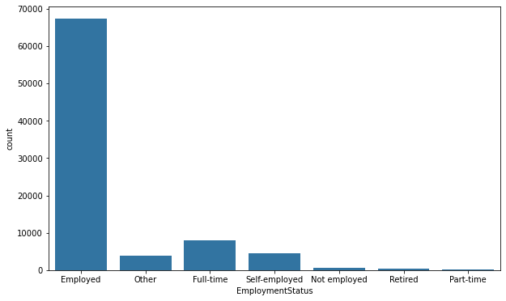

```python
#distribution of employment status
plt.figure(figsize=[10,6])
color = sb.color_palette()[0]
sb.countplot(loan['EmploymentStatus'],color=color)
plt.xlabel('EmploymentStatus');
```

The most of the borrowers employment status is employed. The least borrowers employment status is retired and part time.

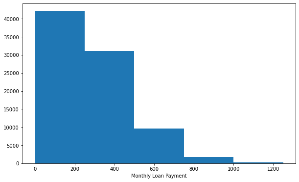

```python
#distribution of monthly loan payments
plt.figure(figsize=[10,6])
bins = np.arange(0,1500, 250)
plt.hist(loan['MonthlyLoanPayment'],bins=bins)
plt.xlabel('Monthly Loan Payment');
```

The most of the borrowers pay upto 250$ monthly for their loans.

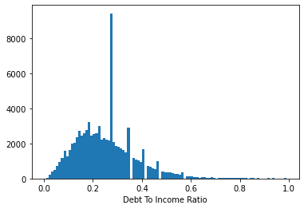

```python
#distribution of debt to income ration
bins = np.arange(0,1, 0.01)
plt.hist(loan['DebtToIncomeRatio'],bins=bins)
plt.xlabel('Debt To Income Ratio');
```

By seeing the distribution, there is huge peak before 0.3 and lowest after 0.3.

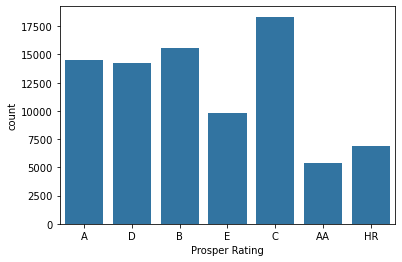

```python
#distribution of prosper ration
color = sb.color_palette()[0]
sb.countplot(data=loan,x='ProsperRating (Alpha)',color=color)
plt.xlabel('Prosper Rating');
```

The most rationg to borrowers is c and least rationg is AA.

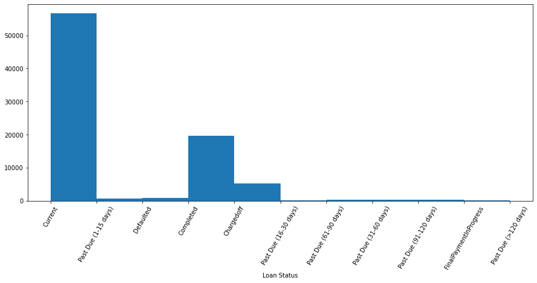

```python
#distribution of loan status
plt.figure(figsize=[15,6])
plt.hist(loan['LoanStatus'])
plt.xlabel('Loan Status')
plt.xticks(rotation=60);
```

By seeing visualization we can say that, most of the loans are active.

### Of the features you investigated, were there any unusual distributions? Did you perform any operations on the data to tidy, adjust, or change the form of the data? If so, why did you do this?

I did not perform any trasformation.

## Bivariate Exploration

Let us see how occupation and employment status of the borrower effects each their monthly loan payments:-

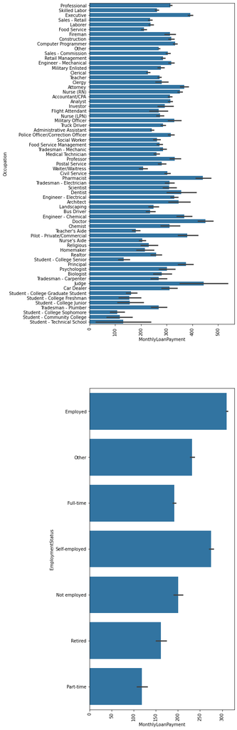

```python
plt.figure(figsize=[6,30])
color = sb.color_palette()[0]

def draw_barplot(x, y):
    sb.barplot(data=loan, x=x,y=y,color=color)
    plt.ylabel(y)
    plt.xlabel(x)
    plt.xticks(rotation=90);

plt.subplot(2,1,1)
draw_barplot('MonthlyLoanPayment', 'Occupation')


plt.subplot(2,1,2)
draw_barplot('MonthlyLoanPayment','EmploymentStatus')
```

The top 3 occupations have high monthly loan payment are Judge, Doctor, and Pharmacist. The plot is consistent with salaries of each occupation. we can say this by seeing plot 2 also employed have high monthly loan payment.

Let us look into relationship of amount deliquent and employment status:-

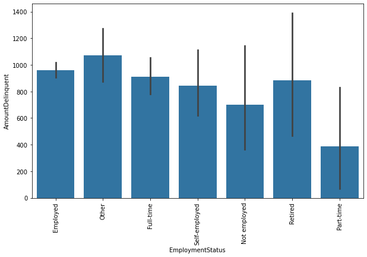

```python
plt.figure(figsize=[10,6])
color = sb.color_palette()[0]

draw_barplot('EmploymentStatus','AmountDelinquent')
# sb.barplot(data=loan, y='AmountDelinquent', x='EmploymentStatus',color=color);
# plt.xlabel('Employment Status')
# plt.ylabel('Amount Delinquent')
# plt.xticks(rotation=90);
```

Now lets see relationship between loan status and prosper rating:-

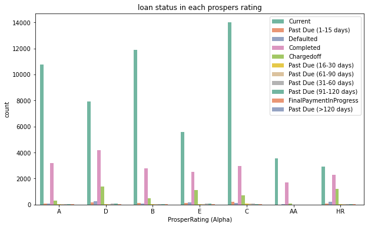

```python
plt.figure(figsize = [10, 6])
sb.countplot(data=loan,x='ProsperRating (Alpha)',hue='LoanStatus',palette='Set2')
plt.legend(loc=1)
plt.title('loan status in each prospers rating');
```

Lower rating were noted on past due and final payment in progress loans and highest rating were noted on current and completed loans.

Now let us see relationship between loan original amount and borrower APR:-

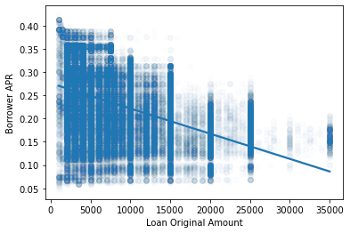

```python
sb.regplot(data=loan, x='LoanOriginalAmount',y='BorrowerAPR',scatter_kws={'alpha':0.01})
plt.xlabel('Loan Original Amount')
plt.ylabel('Borrower APR');
```

The borrower APR is negative correlated with loan amount. It means decrease in APR with the increase of loan amount.

## Multivariate Exploration

Let us see how loan original amount and term of the loan effect the prosper rating:-

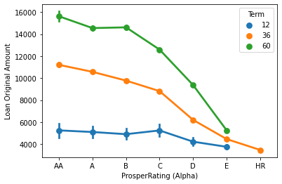

```python
credit_rating = ['AA','A','B','C','D','E','HR']
sb.pointplot(data=loan, x = 'ProsperRating (Alpha)', y = 'LoanOriginalAmount', hue = 'Term',order=credit_rating);
plt.xlabel('ProsperRating (Alpha)')
plt.ylabel('Loan Original Amount');
```

let us see the relationship between credit score ,monthly income and prosper rating:-

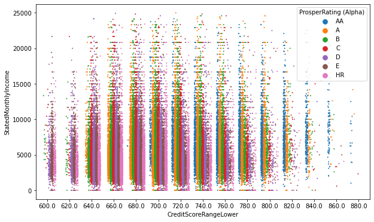

```python
credit_rating = ['AA','A','B','C','D','E','HR']
plt.figure(figsize = [10, 6])
plot = sb.stripplot(data=loan.query('StatedMonthlyIncome<StatedMonthlyIncome.quantile(0.995)'),
                                    x='CreditScoreRangeLower',y='StatedMonthlyIncome',hue='ProsperRating (Alpha)',hue_order=credit_rating,size=2,jitter=0.35,dodge=True)
#plot=sb.FacetGrid(data=loan,hue='ProsperRating (Alpha)',size=5)
#plot.map(plt.scatter,'CreditScoreRangeLower','StatedMonthlyIncome')
#plot.set(yscale = 'log')
#y_ticks=[1,10,100,1000,10000,100000,1000000]
#plot.set(yticks = y_ticks, yticklabels = y_ticks)
#plot.add_legend();
```

### Were there any interesting or surprising interactions between features?

The surprising element was the relationship between credit score and monthly income.